# SpotifyReport

Author

Maud Pals

## My favorite artist: Hozier

#### Who is Hozier?

Hozier is an Irish singer-songwriter with hits such as Take Me To Church and Work Song. His lyrics are often poetic and beautifully written.

#### Hozier’s albums

- Hozier (*2014*)
- Hozier (Special Edition) (*2014*)
- Wasteland, Baby! (*2019*)
- Unreal Unearth (*2023*)

## My favorites

#### My favorite quote

“*These days I think I owe my life to flowers that were left here by my mother. Ain’t that like them? Gifting life to you again.*” - **Hozier** in *First Time*

#### My favorite song and music video

[Hozier - Almost (Sweet Music)](https://www.youtube.com/watch?v=JJ9IX4zgyLs)

[video not shown]

#### My favorite album

Hozier (Special Edition) (*2014*)

[figure not shown]

### Data analysis

#### Source

The data on Hozier’s music used in this analysis was extracted from Spotify using the spotifyr package.

#### Import data

```r
# the packages needed for the analysis
#install.packages("ggplot2")
library(ggplot2)
#install.packages("dplyr")
library(dplyr)
#ggplot2::ggplot()

# importing dataset
Hozier <- read.csv("Hozier.csv")
```

### Data preparation

There are some duplicates that have to be removed. I decided to keep the live versions of the same song as they are quite different.

```r
# removing songs with the same track names
Hozier <- Hozier |> distinct(track_name, .keep_all = TRUE)
# check if I need to change the data type of album_name from numeric to character = not need because the variable is already a character
class(Hozier$album_name)
```

```
[1] "character"
```

#### Album analysis (Valence and Energy)

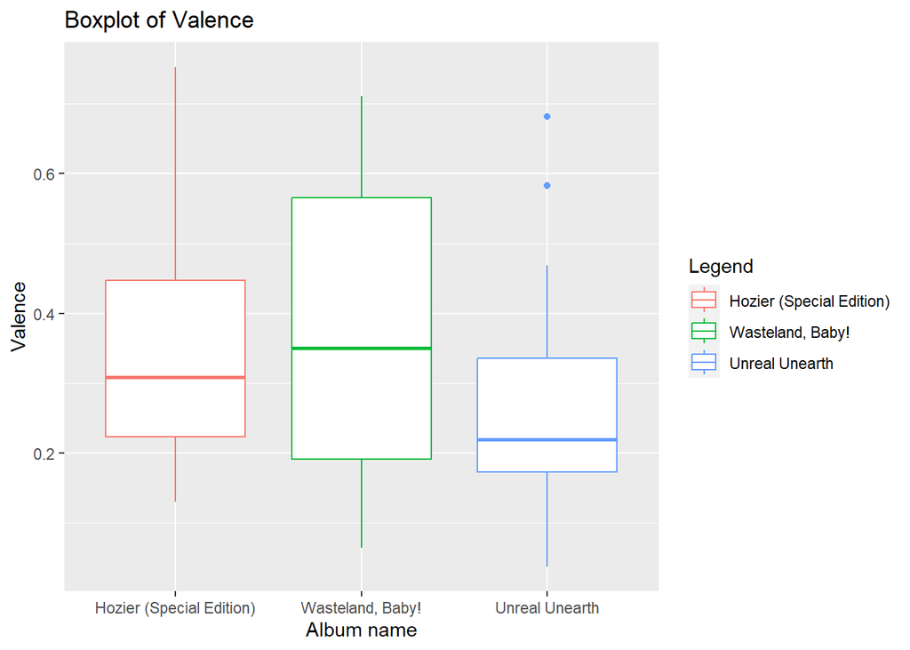

```r
# changing album_name from character to factor before plotting
Hozier$album_name <- as.factor(Hozier$album_name)

# Create a vector with the desired order of album names
desired_order <- c("Hozier", "Hozier (Special Edition)", "Wasteland, Baby!","Unreal Unearth")

# Convert album_name to a factor with the desired order of levels
Hozier$album_name <- factor(Hozier$album_name, levels = desired_order)

# Plot with the reordered album names
ggplot(Hozier, aes(x = album_name, y = valence, color = album_name)) +
  geom_boxplot() +
  labs(title = "Boxplot of Valence", x = "Album name", y = "Valence", color = "Legend")
```

So Hozier’s music has gotten more negative with his last album, with two outliers that are more positive than other songs on the album.

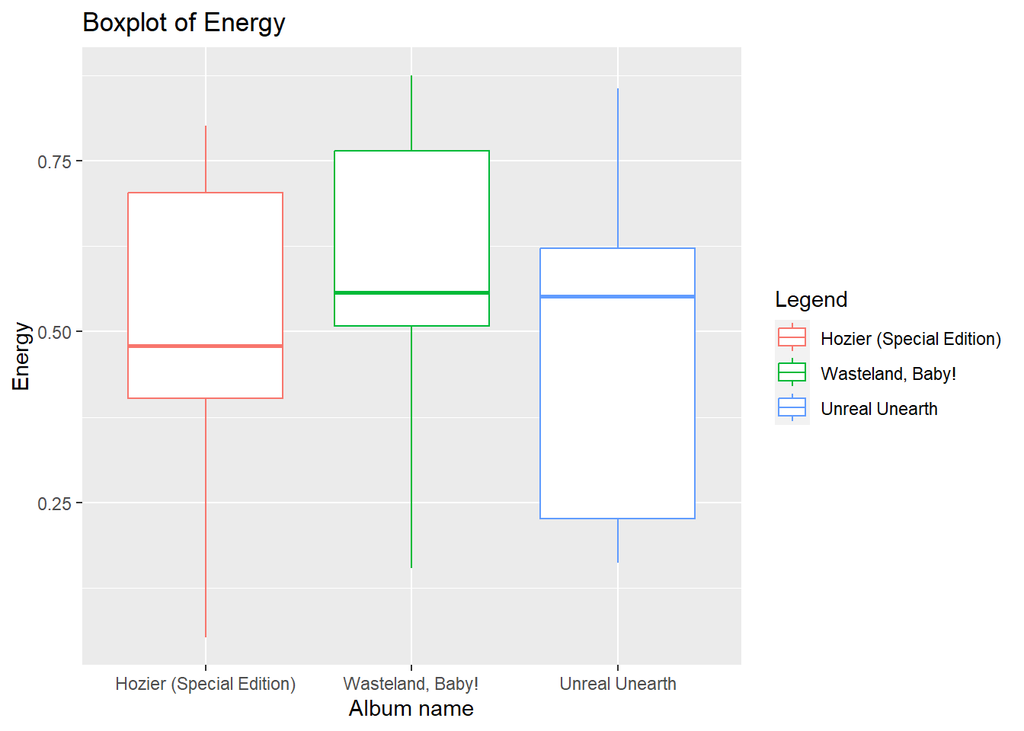

```r
ggplot(Hozier, aes(x = album_name, y = energy, color = album_name)) +
  geom_boxplot() +
  labs(title = "Boxplot of Energy", x = "Album name", y = "Energy", color = "Legend")
```

The median energy has remained similar, however, the range of energy has increased with his latest album.

### Speechiness analysis (Hozier uses a lot of words, usually big words too)

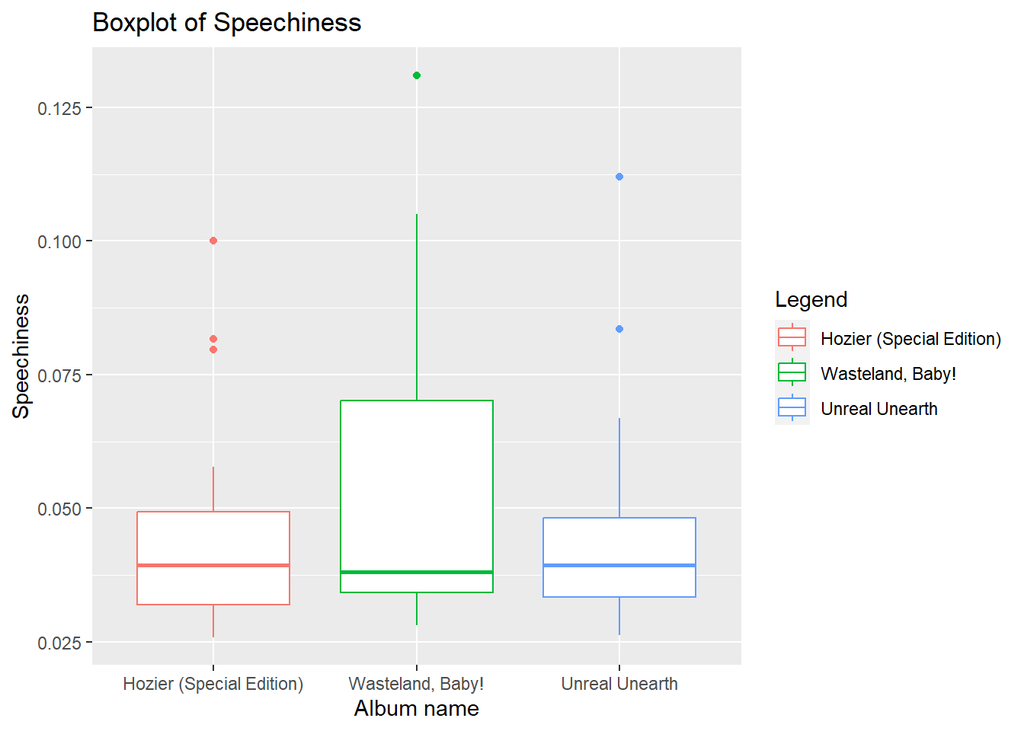

```r
# boxplot speechiness
ggplot(Hozier, aes(x=album_name, y=speechiness, color=album_name))+
  geom_boxplot()+
  labs(title = "Boxplot of Speechiness",x= "Album name", y = "Speechiness", color = "Legend")
```

So the median speechiness in each album has remained the same, however, the range of wordiness has shrunk when comparing the last album to the second one.

### Is there a relationship between the Speechiness and the Valence in Hozier’s songs?

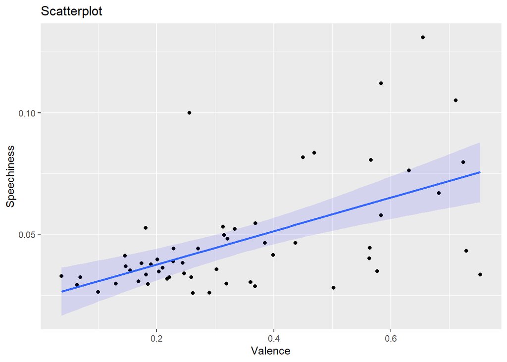

```r
ggplot(Hozier, aes(x = valence, y = speechiness)) +
  geom_point() +
  geom_smooth(method= "lm", alpha = 0.1, fill="blue") +
  labs(title = "Scatterplot", x = "Valence", y = "Speechiness")
```

So the scatterplot shows that the more negative songs are usually less worded, while the more positive songs include more spoken words. I would guess this is due to sad songs usually containing more instrumentals to create a sad feeling.

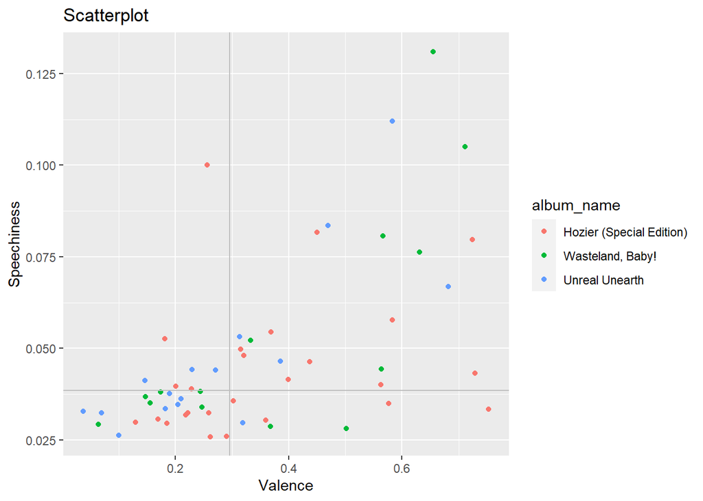

```r
# Calculate midpoint values for x and y axes
x_midpoint <- median(Hozier$valence)
y_midpoint <- median(Hozier$speechiness)

ggplot(Hozier, aes(x = valence, y = speechiness, color = album_name)) +
  geom_point() +
  labs(title = "Scatterplot", x = "Valence", y = "Speechiness")+
  geom_hline(yintercept = y_midpoint, color="grey")+
  geom_vline(xintercept = x_midpoint, color="grey")
```

### What songs are the most wordy?

```r
Hozier |> slice_max(speechiness, n=3) |> dplyr::select(track_name, album_name, album_release_year, speechiness) |> knitr::kable(digits = 2)
```

| track_name | album_name | album_release_year | speechiness |
| --- | --- | --- | --- |
| Nina Cried Power | Wasteland, Baby! | 2019 | 0.13 |
| Anything But | Unreal Unearth | 2023 | 0.11 |
| Almost (Sweet Music) | Wasteland, Baby! | 2019 | 0.10 |

So if you are looking for some good and dense poetry, these three songs are a great start:) In another analysis it could be interesting to look at a measure for how poetic a song is instead of the wordiness as it is a bit more interesting.